# Machine learning

# The expected out of sample error:-

The expected out-of-sample error corresponds to the quantity: one minus accuracy in the cross-validation data. Accuracy is the proportion of correct classified observation over the total sample in the subTesting data set. Expected accuracy is the expected accuracy in the out-of-sample data set (i.e. original testing data set). Thus, the expected value of the out-of-sample error corresponds to the expected number of missclassified observations/total observations in the Test data set.

```r
error<-function(model){
  predictions<-predict(model,testing)
  return(1-as.numeric(confusionMatrix(predictions,testing$classe)$overall[1]))
  }
```

```r
error_cv<-round(error(cv_train),4)
error_rf<-round(error(rf_train),4)
error_gbm<-round(error(gbm_train),4)
error_lda<-round(error(lda_train),4)
all_error<-cbind(error_cv,error_rf,error_gbm,error_lda)
colnames(all_error)<-c("cv","rf","gbm","lda")
all_error
```

```
##          cv     rf    gbm    lda
## [1,] 0.4947 0.0065 0.0336 0.2906
```

# Out of sample error comparison of Models

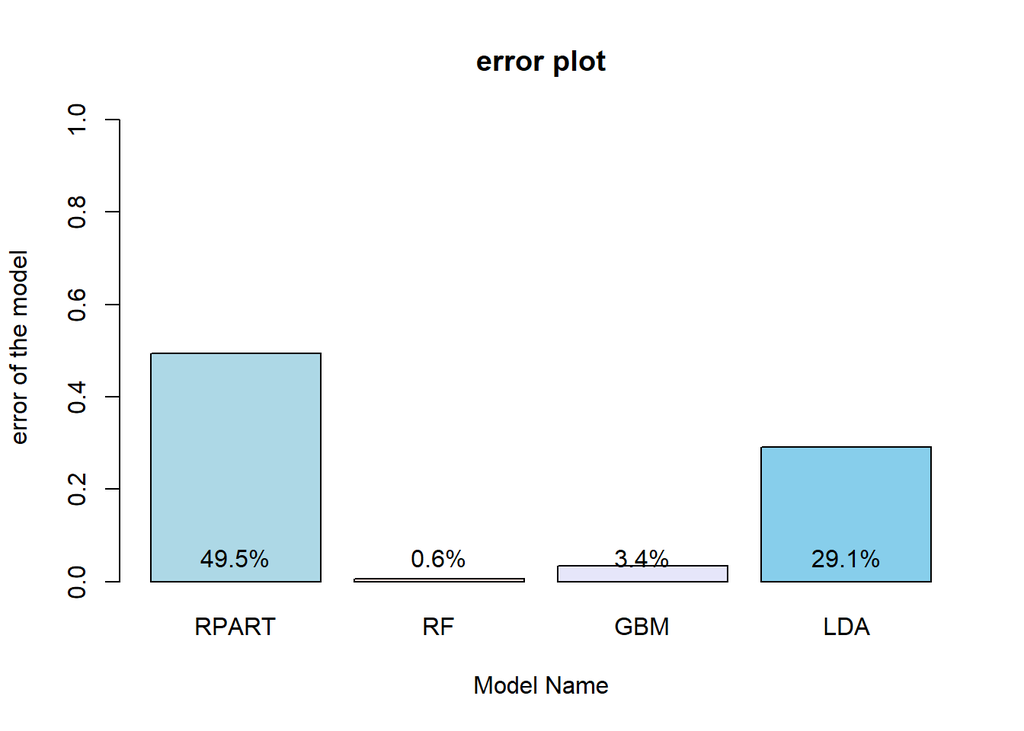

```r
all_error<-c(error_cv,error_rf,error_gbm,error_lda)
names(all_error)<-c("rpart","rf","gbm","lda")

 bp<-barplot(all_error,main="error plot",ylim = c(0,1),names.arg = c("RPART","RF","GBM","LDA"),col = c("lightblue","mistyrose","lavender","skyblue"),ylab = " error of the model",xlab = "Model Name")
text(bp,0,percent(all_error),cex=1,pos=3)
```

From the above bar plot we estimate that the “rf” has very less expected out of sample error.

```r
predict(rf_train, newdata=Testing_Data)
```

```
##  [1] B A B A A E D B A A B C B A E E A B B B
## Levels: A B C D E
```

# Appendix

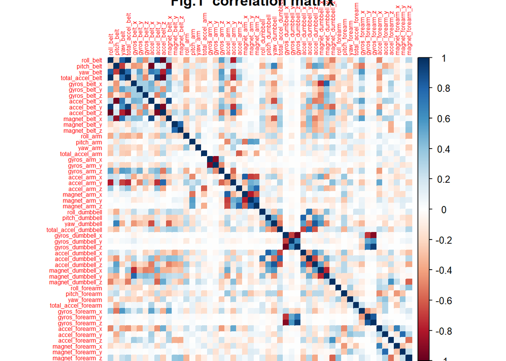

```r
library(corrplot)
corrplot(cor(Training_Data[, -length(names(Training_Data))]), method = "color", tl.cex = 0.5,main="Fig.1  correlation matrix")
```

```r
 library(rattle)
```

[figure not shown]

```r
fancyRpartPlot(cv_train$finalModel,main = "Fig 2.Decision Tree")
```